# 624: Data Processing and Overfitting

Sean Connin

02/28/22

```r
#library(fpp3)
#library(seasonal)
library(magrittr)
library(tidyverse)
library(corrplot)
library(patchwork)
library(forecast)  # for boxcox
library(caret) # for spatial sign transformation
library(mlbench)
library(dlookr)
library(naniar) #missingness
library(flextable)
```

# 1 Kuhn and Johnson: Exercise 3.1

From Applied Predictive Modeling. 2016. Kuhn and Johnson. Exercise 3.1 The UC Irvine Machine Learning Repository contains a data set related to glass identification. The data consist of 214 glass samples labeled as one of seven class categories. There are nine predictors, including the refractive index and percentages of eight elements: Na, Mg, Al, Si, K, Ca, Ba, and Fe.

```r
# read in glass data

data(Glass)

# save in working file

glass<-Glass

# review data

glass%>%head(3)%>%
  flextable()%>%
  set_caption('Glass Dataset: Subset of Observations')
```

Glass Dataset: Subset of Observations

| RI | Na | Mg | Al | Si | K | Ca | Ba | Fe | Type |
| --- | --- | --- | --- | --- | --- | --- | --- | --- | --- |
| 1.52101 | 13.64 | 4.49 | 1.10 | 71.78 | 0.06 | 8.75 | 0 | 0 | 1 |
| 1.51761 | 13.89 | 3.60 | 1.36 | 72.73 | 0.48 | 7.83 | 0 | 0 | 1 |
| 1.51618 | 13.53 | 3.55 | 1.54 | 72.99 | 0.39 | 7.78 | 0 | 0 | 1 |

3.1a. Using visualizations, explore the predictor variables to understand their distributions as well as the relationships between predictors.

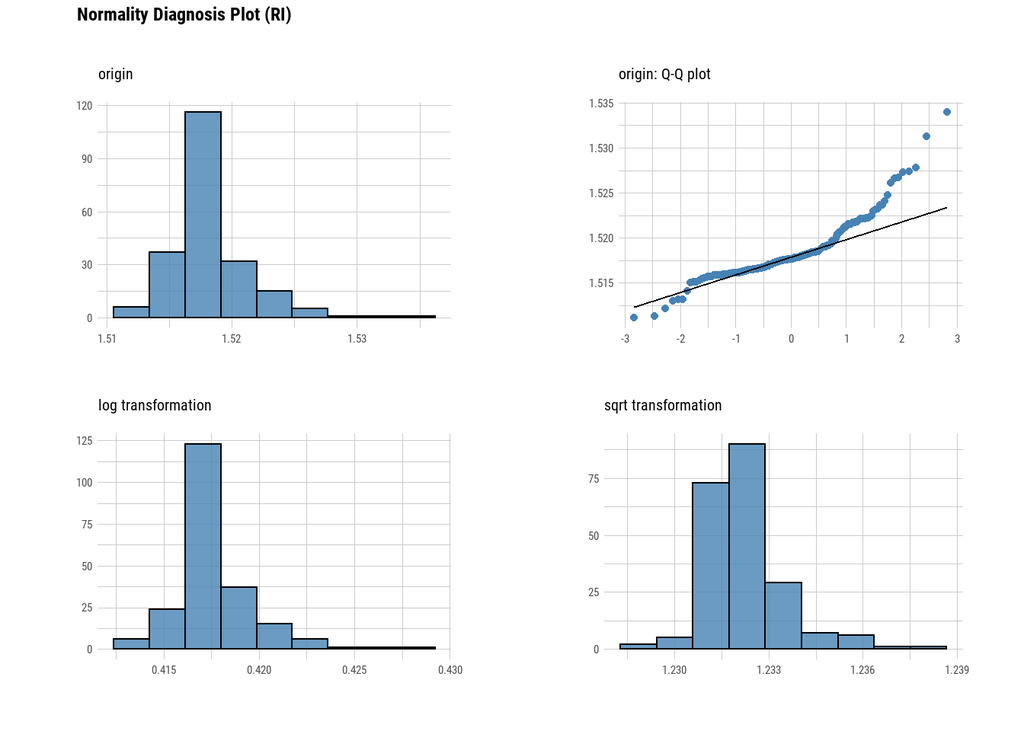

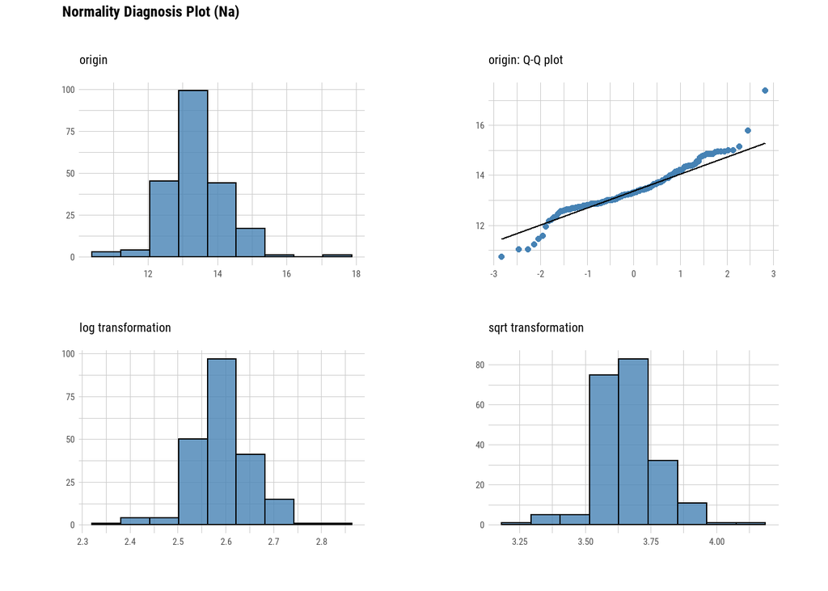

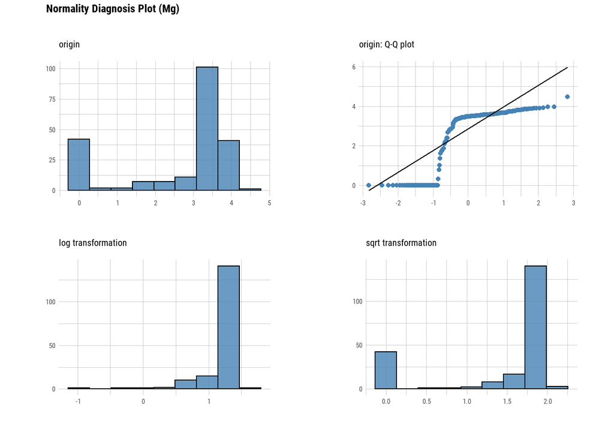

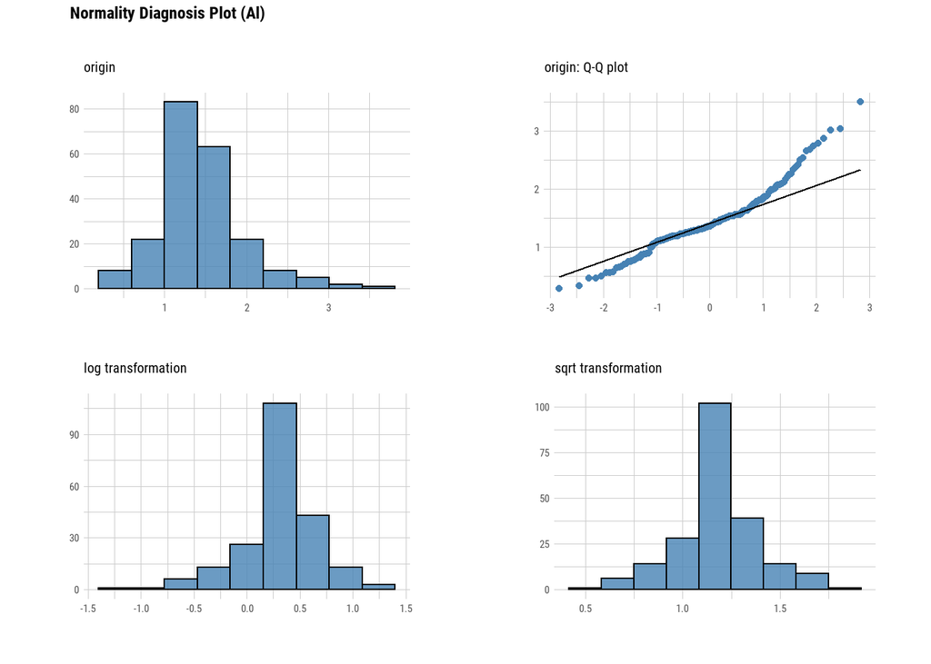

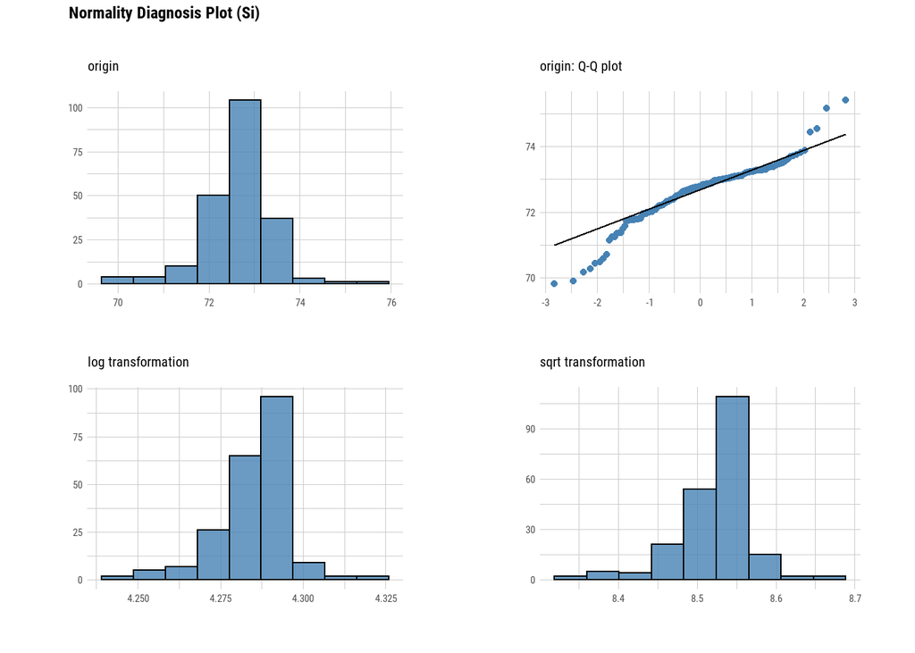

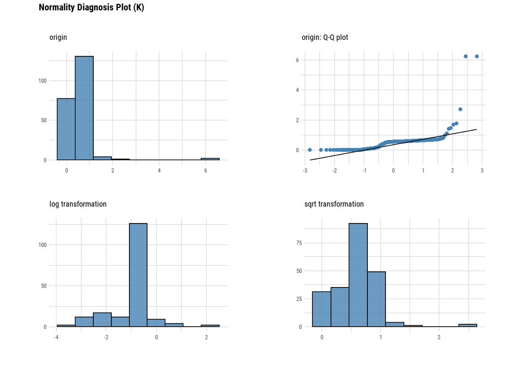

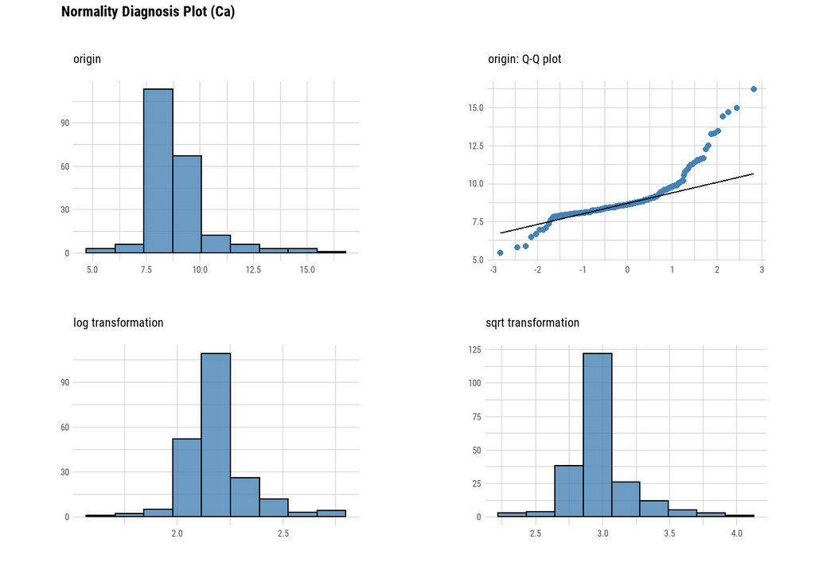

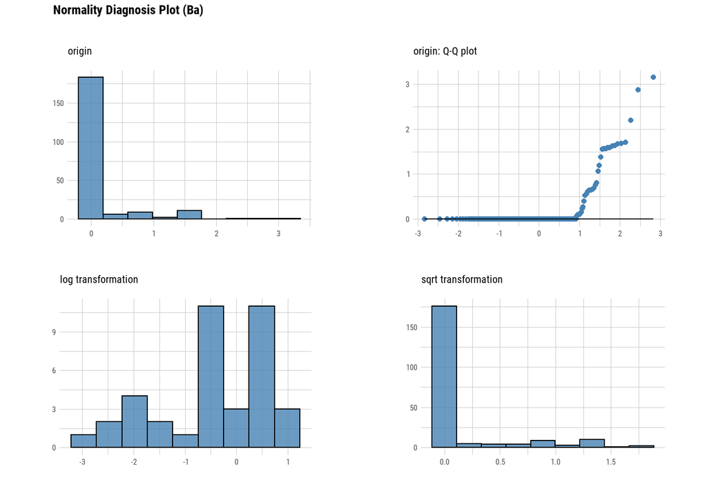

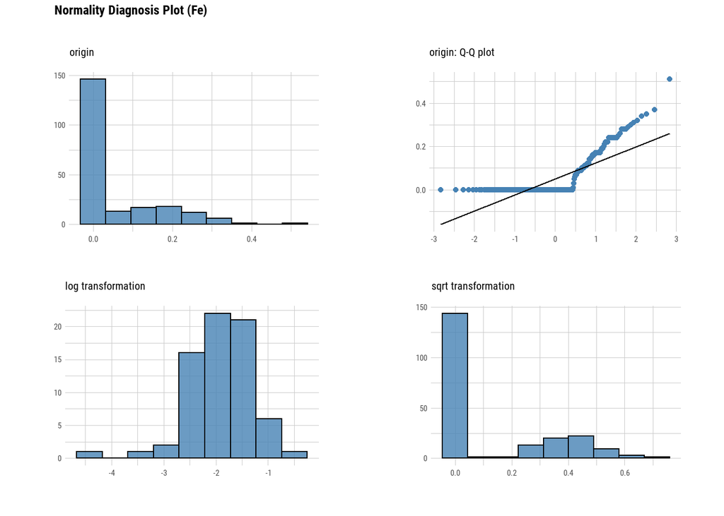

```r
# plot distributions using dlookr

glass%>%plot_normality()
```

Pairwise comparisons to evaluate relationships between predictors.

*An argument can be made for dropping either Ba or Ca for modeling purposes given that they account for similar variance. As Ba also correlates with Si, it may be prudent to retain Ca.*

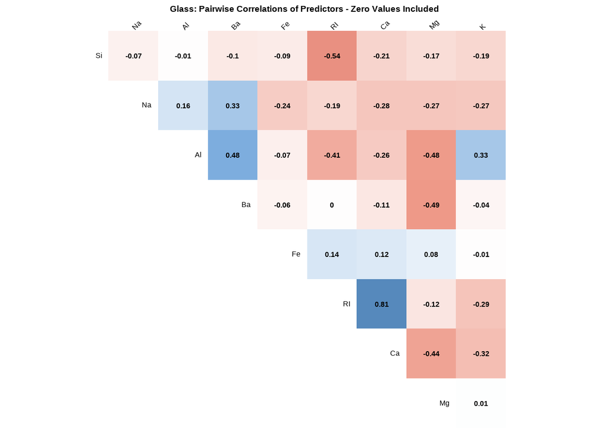

```r
#create correlation matrix that includes all numerical values

glass_cor <-glass%>%
  select(-Type)%>%
  cor()

#set colors

col <- colorRampPalette(c("#BB4444", "#EE9988", "#FFFFFF", "#77AADD", "#4477AA"))

# plot pairwise correlations with zero values included

corrplot(glass_cor, method = "shade",
         shade.col = NA,
         diag=FALSE,
         type='upper',
         tl.col = "black",
         tl.srt = 45,
         addCoef.col = "black",
         cl.pos = "n",
         order = "hclust",
         col = col(200),
         title ='Glass: Pairwise Correlations of Predictors - Zero Values Included' ,
         mar=c(0,0,1,0))
```

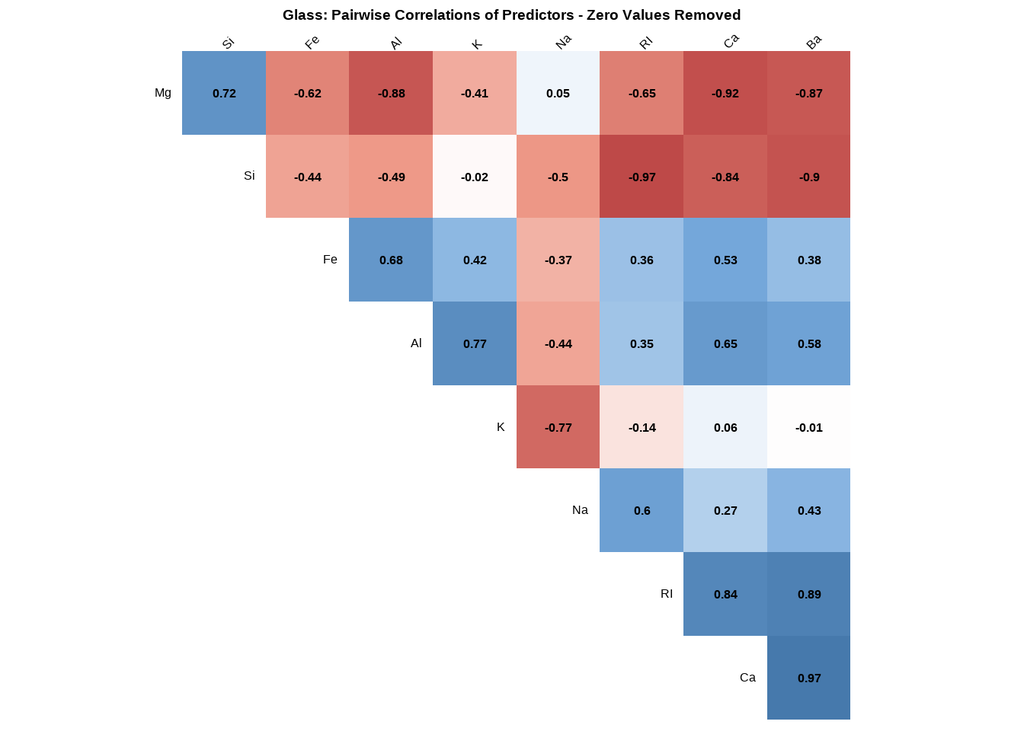

```r
#plot pairwise correlations removing the zeros

less_cor<-glass%>%
  select(-Type)%>%
  filter_if(is.numeric, all_vars((.) != 0))%>%
  cor()


corrplot(less_cor, method = "shade",
         shade.col = NA,
         diag=FALSE,
         type='upper',
         tl.col = "black",
         tl.srt = 45,
         addCoef.col = "black",
         cl.pos = "n",
         order = "hclust",
         col = col(200),
         title ='Glass: Pairwise Correlations of Predictors - Zero Values Removed' ,
         mar=c(0,0,1,0))
```

3.1b. Do there appear to be any outliers in the data? Are any predictors skewed?

*Yes, the covariates with skewed distributions include: “RI” “Mg” “K” “Ca” “Ba” “Fe”. From this list, Ba and Ca also have the highest proportion of outliers (17% and 12%, respectively). The following table and plots provide a summary of these measures.*

```r
# Identify predictors that are highly skewed

skew<-glass%>%find_skewness(index=FALSE, thres=TRUE)

print(paste(cat(skew), "display a skewed distributions."))
```

```
## RI Mg K Ca Ba Fe[1] " display a skewed distributions."
```

```r
# identify outliers -- above q0.75+1.5*IQR and below q0.25+1.5*IQR

diagnose_outlier(glass)%>%arrange(desc(outliers_cnt)) %>%
  mutate_if(is.numeric, round , digits=3)%>%
  flextable()%>%
  set_caption("Glass: Outlier Statistics")
```

Glass: Outlier Statistics

| variables | outliers_cnt | outliers_ratio | outliers_mean | with_mean | without_mean |
| --- | --- | --- | --- | --- | --- |
| Ba | 38 | 17.757 | 0.986 | 0.175 | 0.000 |
| Ca | 26 | 12.150 | 11.173 | 8.957 | 8.651 |
| Al | 18 | 8.411 | 2.088 | 1.445 | 1.386 |
| RI | 17 | 7.944 | 1.524 | 1.518 | 1.518 |
| Si | 12 | 5.607 | 71.824 | 72.651 | 72.700 |
| Fe | 12 | 5.607 | 0.324 | 0.057 | 0.041 |
| Na | 7 | 3.271 | 12.661 | 13.408 | 13.433 |
| K | 7 | 3.271 | 3.061 | 0.497 | 0.410 |
| Mg | 0 | 0.000 |  | 2.685 | 2.685 |

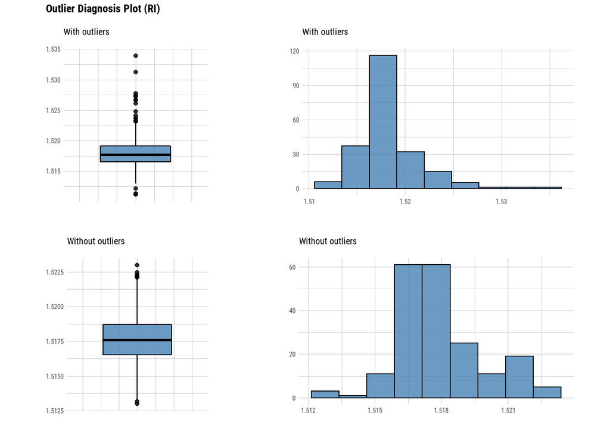

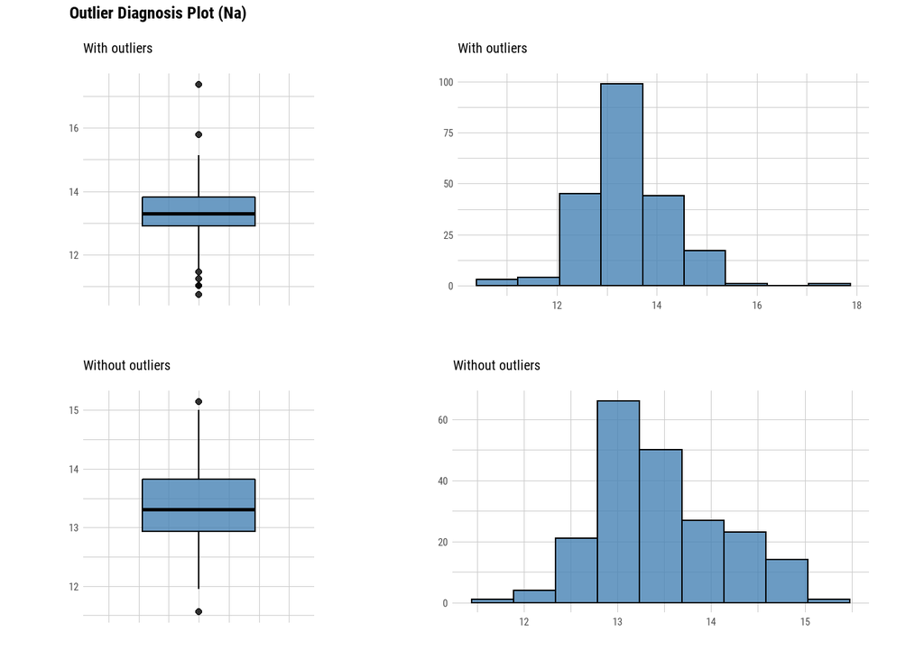

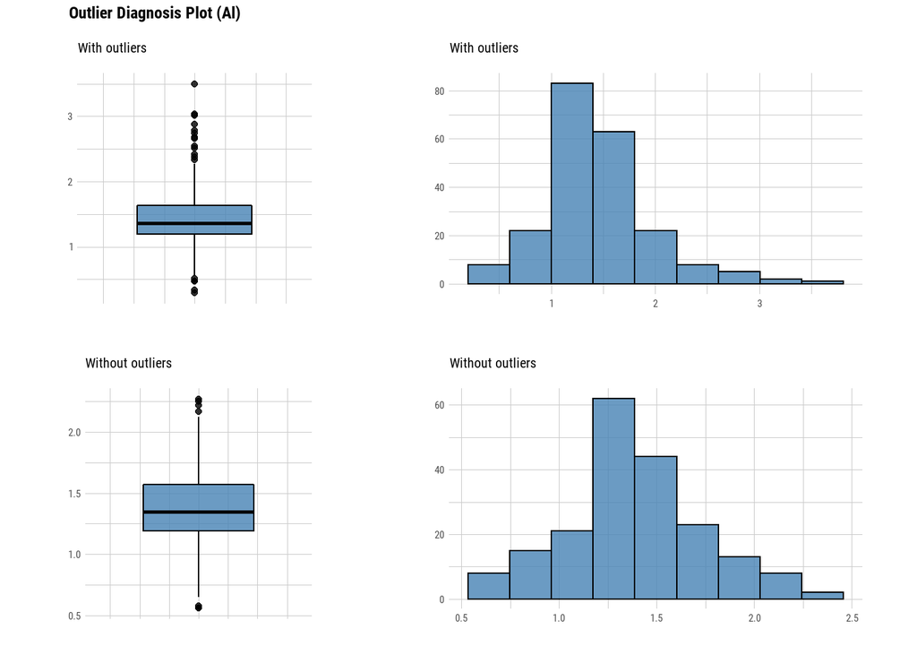

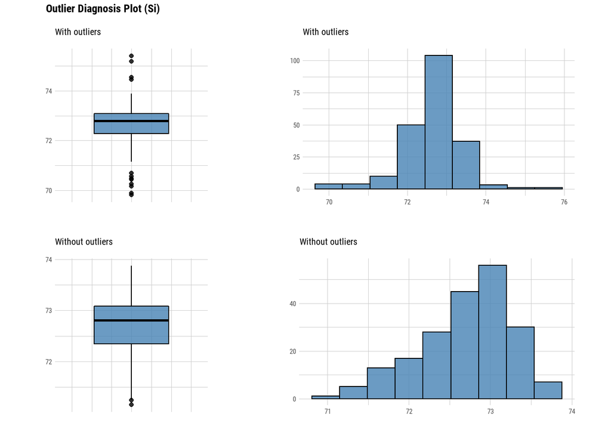

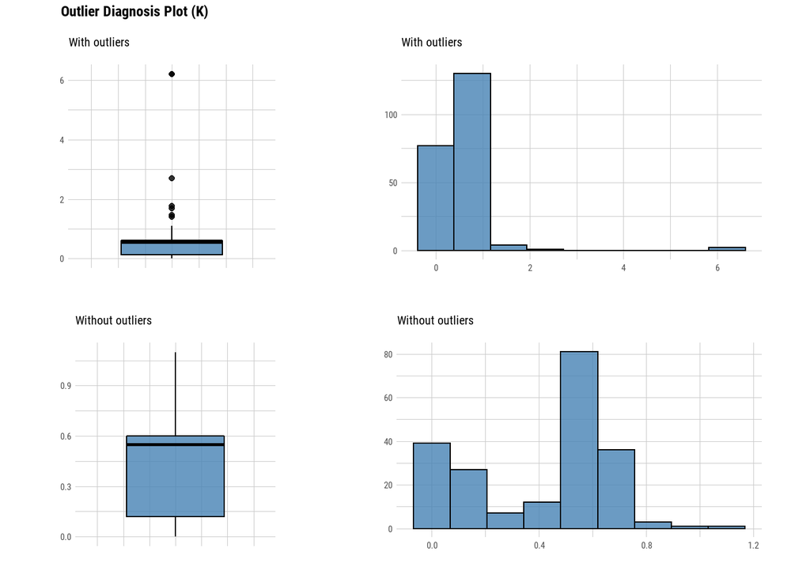

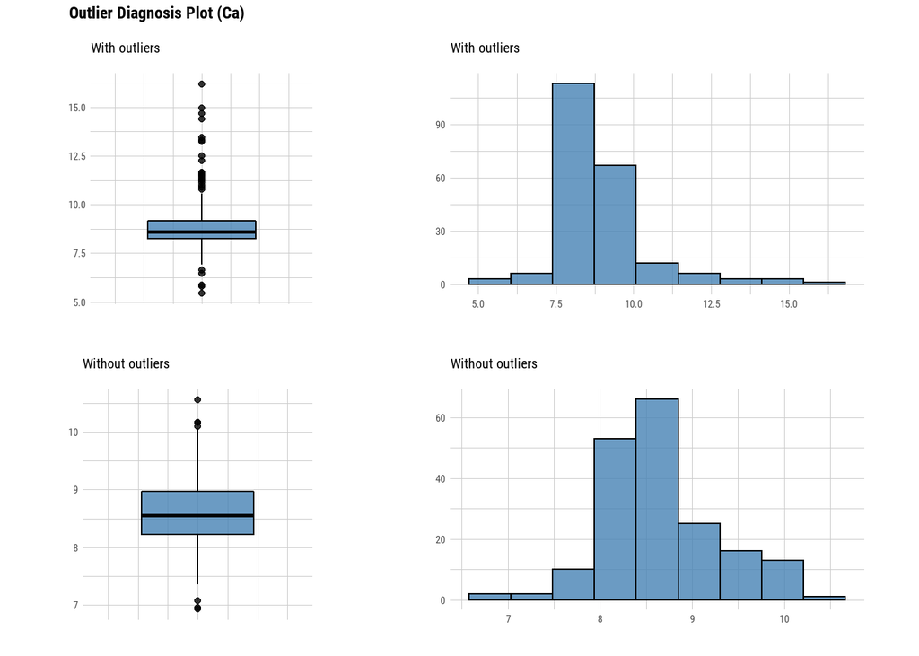

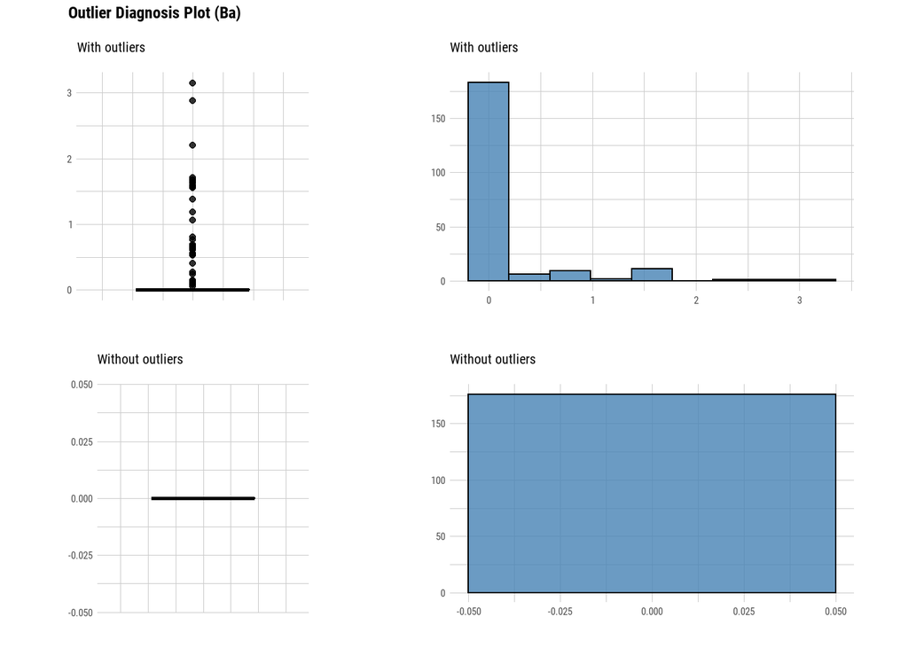

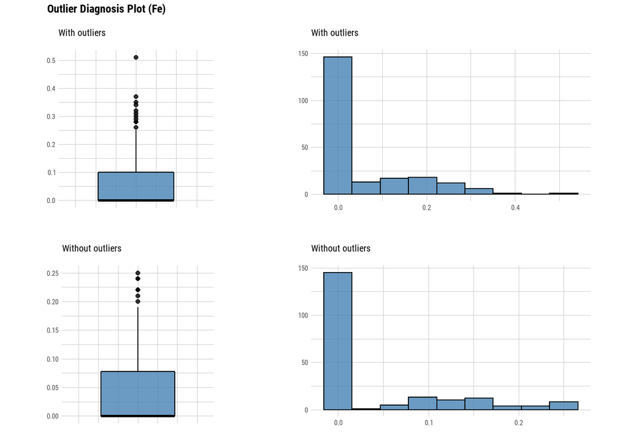

```r
# assess change to distributions based on outlier removal

glass %>%
    select(find_outliers(glass, index = FALSE)) %>%
    plot_outlier()
```

3.1c. Are there any relevant transformations of one or more predictors that might improve the classification model?

*Given that few of the covariates have near normal distributions, we can employ a Box_Cox estimation of lambda to select an appropriate transformation method. On this basis, the following covariates are listed with the ‘best-in-class’ transformation.*

- *RI - inverse*
- *Na - inverse or inverse sqrt*
- *Mg - no transformation*
- *Al - sqrt or log*
- *Si - Inverse*
- *K - log*
- *Ca - inverse sqrt*
- *Ba - log*
- *Fe - log*

*A spatialSign transformation may also be appropriate for covariates that have a significant number of outliers (particularly if they are influential observations). In this Glass dataset, the covariates Ca and Ba are good candidates for the spatialSign transform. The plots below compare untransformed, spatialSign transformed, and lamba transformed distributions for these covariates. The choice of one transformation vs. another may be best evaluated from other model diagnostics and measures of fit.*

```r
#using boxcox from forecast pkg (we could use MASS as alternative)

g<-glass%>%select(-Type)
type<-glass%>%select(Type)

g%>%map(BoxCox.lambda)%>%
  as.data.frame()%>%
  flextable()%>%
  set_caption('Box-Cox Lambdas for Glass Predictors')
```

Box-Cox Lambdas for Glass Predictors

| RI | Na | Mg | Al | Si | K | Ca | Ba | Fe |
| --- | --- | --- | --- | --- | --- | --- | --- | --- |
| -0.9999242 | -0.7425332 | 0.9999895 | 0.3616362 | -0.9999242 | 0.0634853 | -0.3850341 | 0.08844884 | 0.1314834 |

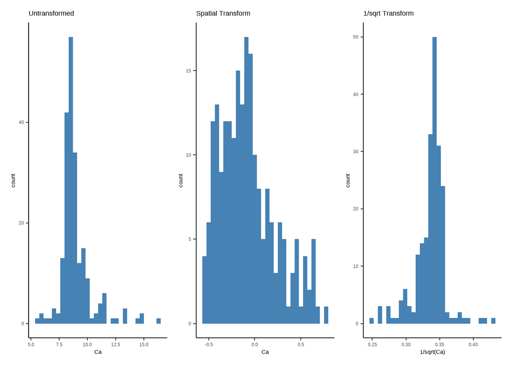

```r
# Compare transformations on Ca and Ba distributions

spatial<- preProcess(glass[, -10], method=c('center', 'scale'))
spatial_2<- predict(spatial, glass[,-10])
spatial_3<-spatialSign(spatial_2)
spatial_3<-as.data.frame(spatial_3)

ca1<-glass%>%ggplot(aes(x=Ca))+
  geom_histogram(fill='steelblue')+
  theme_classic()+
  labs(title='Untransformed')

ca2<-spatial_3%>%ggplot(aes(x=Ca))+
  geom_histogram(fill='steelblue')+
  theme_classic()+
  labs(title='Spatial Transform')

ca3<-glass%>%ggplot(aes(x=1/sqrt(Ca)))+
  geom_histogram(fill='steelblue')+
  theme_classic()+
  labs(title='1/sqrt Transform')

ba1<-glass%>%ggplot(aes(x=Ba))+
  geom_histogram(fill='steelblue')+
  theme_classic()+
  labs(title='Untransformed')

ba2<-spatial_3%>%ggplot(aes(x=Ba))+
  geom_histogram(fill='steelblue')+
  theme_classic()+
  labs(title='Spatial Transform')

ba3<-glass%>%ggplot(aes(x=log(Ba)))+
  geom_histogram(fill='steelblue')+
  theme_classic()+
  labs(title='Log Transform')

# plot comparisons

ca1|ca2|ca3
```

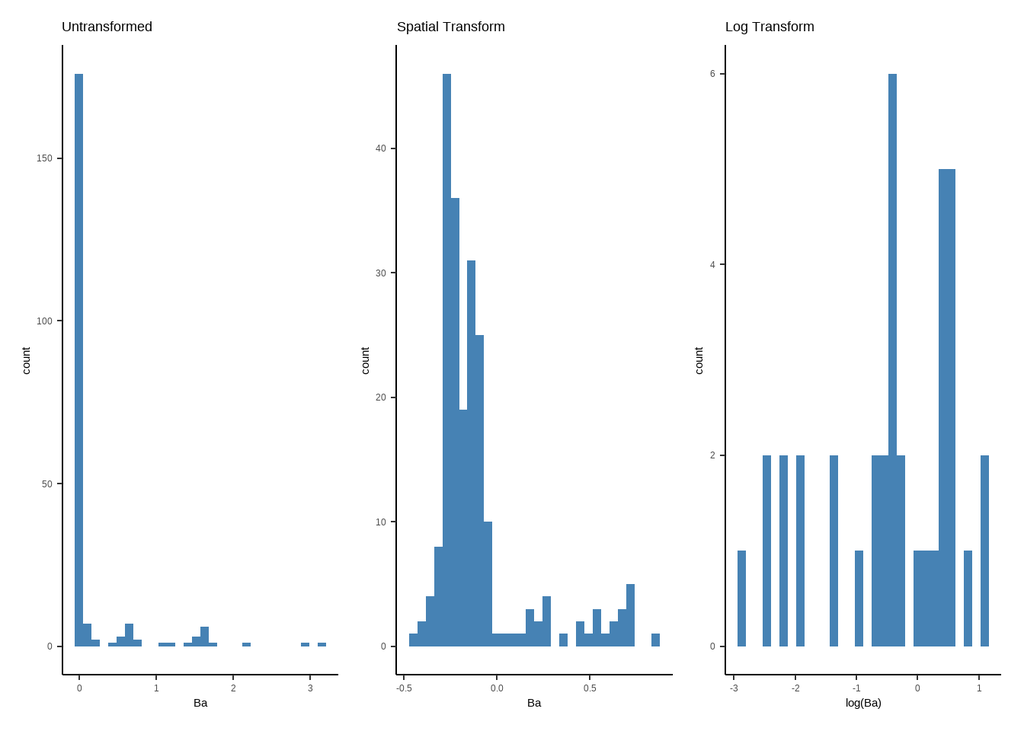

```r
ba1|ba2|ba3
```

*The following scatter plot matrices are included to show pair-wise comparisons between untransformed and spatialSign transformed covariates. The first matrix displays the untransformed observations.*

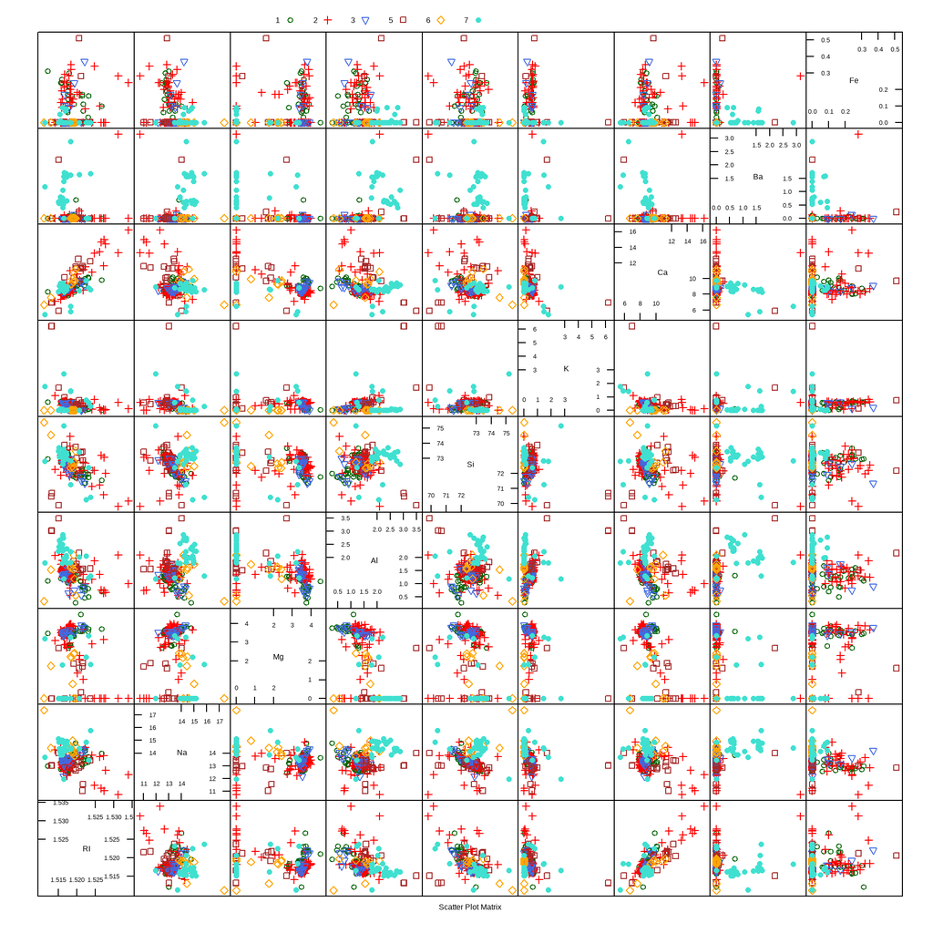

```r
#based on http://rismyhammer.com/ml/OutliersSpatialSign.html#:~:text=Use%20spatialSign%20%28%29%20in%20caret%20to%20conduct%20spatial,myTransformed2%20%3C-%20spatialSign%28myTransformed%29%20myTransformed2%20%3C-%20as.data.frame%28myTransformed2%29%20head%28myTransformed2%2C%2010%29

#Plot spatial sign transformation using caret. Col 10 = 'Type'

trellis.par.set(theme = col.whitebg(), warn = FALSE)

featurePlot(glass[,-10], glass[,10], "pairs",  auto.key = list(columns = 10))
```

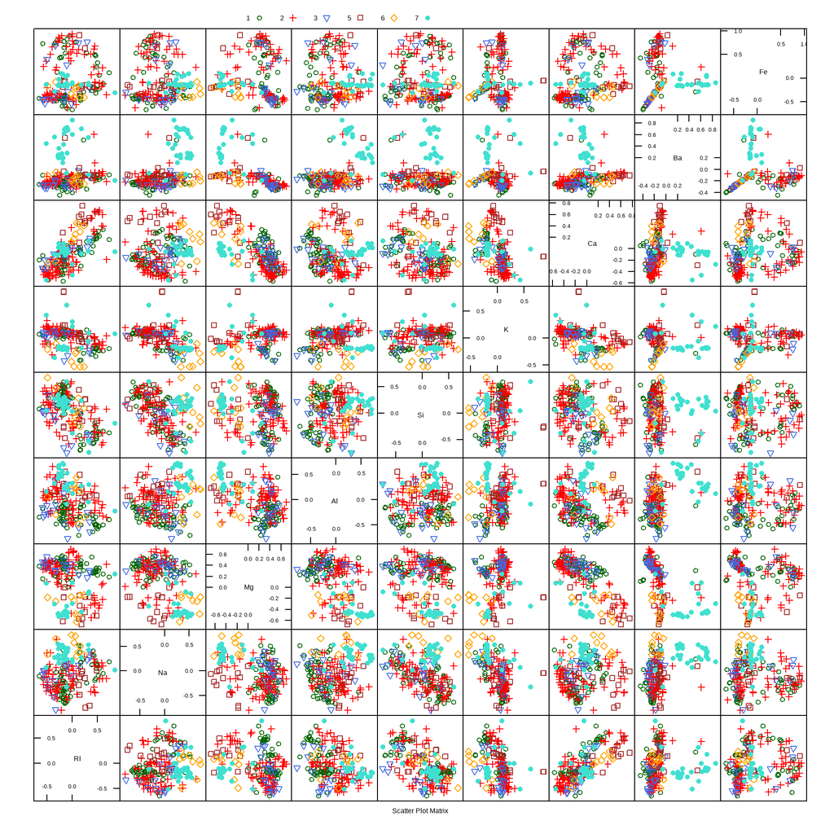

```r
featurePlot(spatialSign(scale(glass[,-10])), glass[,10], "pairs", auto.key = list(columns = 10))
```

# 2 Kuhn and Johnson: Exercise 3.2

3.2. Soybean data can also be found at the UC Irvine Machine Learning Repository. Data were collected to predict disease in 683 soybeans. The 35 predictors are mostly categorical and include information on the environmental conditions (e.g., temperature, precipitation) and plant conditions (e.g., left spots, mold growth). The outcome labels consist of 19 distinct classes.

```r
#load soybeen data

data(Soybean)

soybean<-Soybean

# print selection of dataset

soybean%>%head(3)%>%
  flextable()%>%
  set_caption("Soybean Dataset: Subset of Observations")
```

Soybean Dataset: Subset of Observations

| Class | date | plant.stand | precip | temp | hail | crop.hist | area.dam | sever | seed.tmt | germ | plant.growth | leaves | leaf.halo | leaf.marg | leaf.size | leaf.shread | leaf.malf | leaf.mild | stem | lodging | stem.cankers | canker.lesion | fruiting.bodies | ext.decay | mycelium | int.discolor | sclerotia | fruit.pods | fruit.spots | … |
| --- | --- | --- | --- | --- | --- | --- | --- | --- | --- | --- | --- | --- | --- | --- | --- | --- | --- | --- | --- | --- | --- | --- | --- | --- | --- | --- | --- | --- | --- | --- |
| diaporthe-stem-canker | 6 | 0 | 2 | 1 | 0 | 1 | 1 | 1 | 0 | 0 | 1 | 1 | 0 | 2 | 2 | 0 | 0 | 0 | 1 | 1 | 3 | 1 | 1 | 1 | 0 | 0 | 0 | 0 | 4 | … |
| diaporthe-stem-canker | 4 | 0 | 2 | 1 | 0 | 2 | 0 | 2 | 1 | 1 | 1 | 1 | 0 | 2 | 2 | 0 | 0 | 0 | 1 | 0 | 3 | 1 | 1 | 1 | 0 | 0 | 0 | 0 | 4 | … |
| diaporthe-stem-canker | 3 | 0 | 2 | 1 | 0 | 1 | 0 | 2 | 1 | 2 | 1 | 1 | 0 | 2 | 2 | 0 | 0 | 0 | 1 | 0 | 3 | 0 | 1 | 1 | 0 | 0 | 0 | 0 | 4 | … |

3.2a. Investigate the frequency distributions for the categorical predictors.

*The following table and plots provide a summary of the frequency distributions. They provide a quick means to screen for low/zero variance covariates (discussed in the next prompt) as well as class imbalance.*

```r
# calculate frequency distributions of categorical predictor variables

soybean%>%
  select(!Class)%>%
  diagnose_category()%>%
  flextable()%>%
  set_caption("Soybean: Frequency Statistics for Predictor Variables")
```

Soybean: Frequency Statistics for Predictor Variables

| variables | levels | N | freq | ratio | rank |
| --- | --- | --- | --- | --- | --- |
| date | 5 | 683 | 149 | 21.8155198 | 1 |
| date | 4 | 683 | 131 | 19.1800878 | 2 |
| date | 3 | 683 | 118 | 17.2767204 | 3 |
| date | 2 | 683 | 93 | 13.6163982 | 4 |
| date | 6 | 683 | 90 | 13.1771596 | 5 |
| date | 1 | 683 | 75 | 10.9809663 | 6 |
| date | 0 | 683 | 26 | 3.8067350 | 7 |
| date |  | 683 | 1 | 0.1464129 | 8 |
| plant.stand | 0 | 683 | 354 | 51.8301611 | 1 |
| plant.stand | 1 | 683 | 293 | 42.8989751 | 2 |
| plant.stand |  | 683 | 36 | 5.2708638 | 3 |
| precip | 2 | 683 | 459 | 67.2035139 | 1 |
| precip | 1 | 683 | 112 | 16.3982430 | 2 |
| precip | 0 | 683 | 74 | 10.8345534 | 3 |
| precip |  | 683 | 38 | 5.5636896 | 4 |
| temp | 1 | 683 | 374 | 54.7584187 | 1 |
| temp | 2 | 683 | 199 | 29.1361640 | 2 |
| temp | 0 | 683 | 80 | 11.7130307 | 3 |
| temp |  | 683 | 30 | 4.3923865 | 4 |
| hail | 0 | 683 | 435 | 63.6896047 | 1 |
| hail | 1 | 683 | 127 | 18.5944363 | 2 |
| hail |  | 683 | 121 | 17.7159590 | 3 |
| crop.hist | 2 | 683 | 219 | 32.0644217 | 1 |
| crop.hist | 3 | 683 | 218 | 31.9180088 | 2 |
| crop.hist | 1 | 683 | 165 | 24.1581259 | 3 |
| crop.hist | 0 | 683 | 65 | 9.5168375 | 4 |
| crop.hist |  | 683 | 16 | 2.3426061 | 5 |
| area.dam | 1 | 683 | 227 | 33.2357247 | 1 |
| area.dam | 3 | 683 | 187 | 27.3792094 | 2 |
| area.dam | 2 | 683 | 145 | 21.2298682 | 3 |

[output cut: 103 more lines]

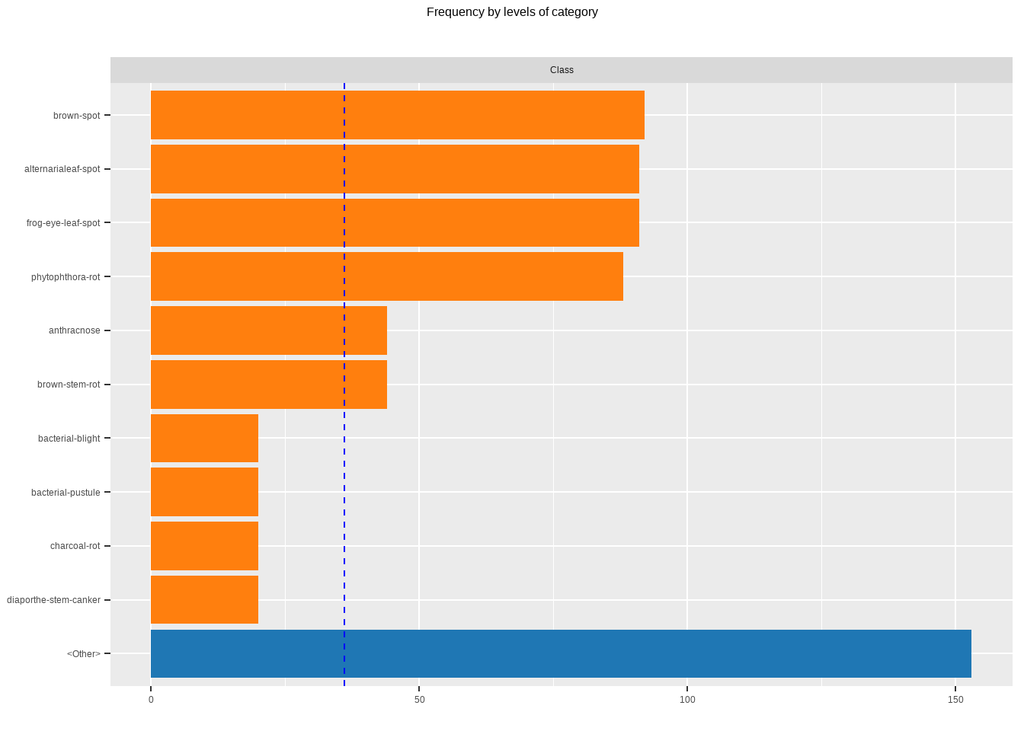

```r
# plot frequency distributions for categorical predictors

soybean %>%
  select(c(,1))%>%
  plot_bar_category(typographic = FALSE, each=FALSE)
```

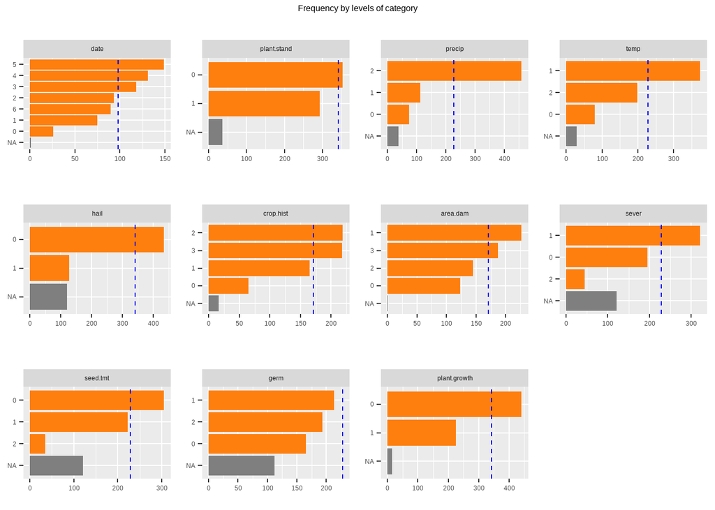

```r
soybean %>%
  select(c(,2:12))%>%
  plot_bar_category(typographic = FALSE, each=FALSE)
```

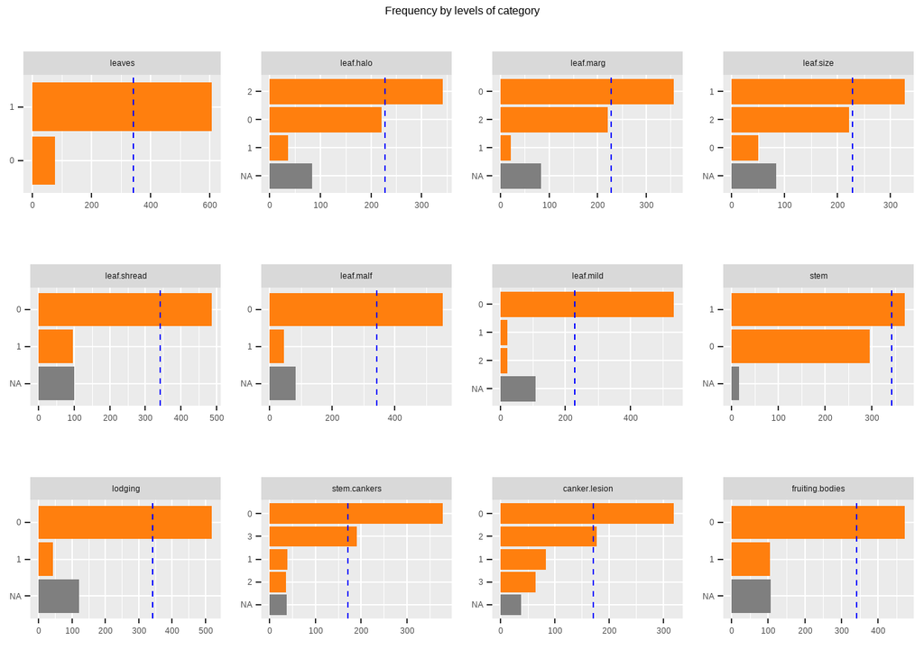

```r
soybean %>%
  select(c(,13:24))%>%
  plot_bar_category(typographic = FALSE, each=FALSE)
```

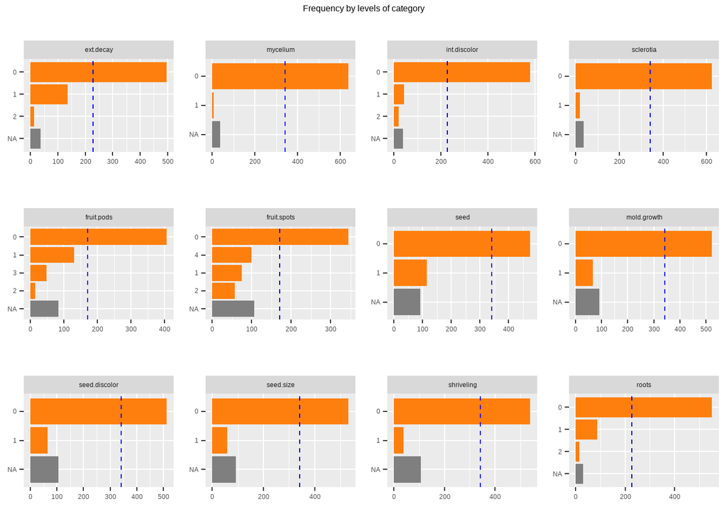

```r
soybean %>%
  select(c(,25:36))%>%
  plot_bar_category(typographic = FALSE, each=FALSE)
```

Are any of the distributions degenerate in the ways discussed earlier in this chapter?

*A degenerate distribution is comprised of a single random variable with a single value. The Soybean dataset does not include covariates that have strictly degenerate distributions. However, there are several covariates that have near zero variance (nearly degenerate) - i.e. almost all observations belong to one level of the covariate. Included are the covariates ‘mycelium’ and ‘sclerotia’.*

```r
soybean%>%
  diagnose_category()%>%
  filter(ratio>90)%>%
  arrange(desc = TRUE)%>%
    flextable()
```

| variables | levels | N | freq | ratio | rank |
| --- | --- | --- | --- | --- | --- |
| mycelium | 0 | 683 | 639 | 93.55783 | 1 |
| sclerotia | 0 | 683 | 625 | 91.50805 | 1 |

3.2b. Roughly 18 % of the data are missing. Are there particular predictors that are more likely to be missing? Is the pattern of missing data related to the classes?

*The propensity for missingess among predictors owes more to aspects of data collection than what we might infer from the available data. Variables that are difficult/costly to collect are more apt to have high proportions of missingness.*

*In the soybeans dataset there is a pattern of missing data that relates to the Class variable. For example, the following class levels have very high levels of missingness: 2-4-d-injury, cyst-nematode, diaporthe-pod-&-stem-blight, herbicide injury, and phytophthora-rot.*

```r
# calculate missingness statistics across variables

soybean%>%
    diagnose()%>%
    dplyr::select(-unique_count, -unique_rate)%>%
    filter(missing_count>0)%>%
    arrange(desc(missing_count))%>%
    flextable()%>%
    set_caption("Missing Data Summary: Soybean")
```

Missing Data Summary: Soybean

| variables | types | missing_count | missing_percent |
| --- | --- | --- | --- |
| hail | factor | 121 | 17.7159590 |
| sever | factor | 121 | 17.7159590 |
| seed.tmt | factor | 121 | 17.7159590 |
| lodging | factor | 121 | 17.7159590 |
| germ | ordered | 112 | 16.3982430 |
| leaf.mild | factor | 108 | 15.8125915 |
| fruiting.bodies | factor | 106 | 15.5197657 |
| fruit.spots | factor | 106 | 15.5197657 |
| seed.discolor | factor | 106 | 15.5197657 |
| shriveling | factor | 106 | 15.5197657 |
| leaf.shread | factor | 100 | 14.6412884 |
| seed | factor | 92 | 13.4699854 |
| mold.growth | factor | 92 | 13.4699854 |
| seed.size | factor | 92 | 13.4699854 |
| leaf.halo | factor | 84 | 12.2986823 |
| leaf.marg | factor | 84 | 12.2986823 |
| leaf.size | ordered | 84 | 12.2986823 |
| leaf.malf | factor | 84 | 12.2986823 |
| fruit.pods | factor | 84 | 12.2986823 |
| precip | ordered | 38 | 5.5636896 |
| stem.cankers | factor | 38 | 5.5636896 |
| canker.lesion | factor | 38 | 5.5636896 |
| ext.decay | factor | 38 | 5.5636896 |
| mycelium | factor | 38 | 5.5636896 |
| int.discolor | factor | 38 | 5.5636896 |
| sclerotia | factor | 38 | 5.5636896 |
| plant.stand | ordered | 36 | 5.2708638 |
| roots | factor | 31 | 4.5387994 |
| temp | ordered | 30 | 4.3923865 |
| crop.hist | factor | 16 | 2.3426061 |
| plant.growth | factor | 16 | 2.3426061 |
| stem | factor | 16 | 2.3426061 |
| date | factor | 1 | 0.1464129 |
| area.dam | factor | 1 | 0.1464129 |

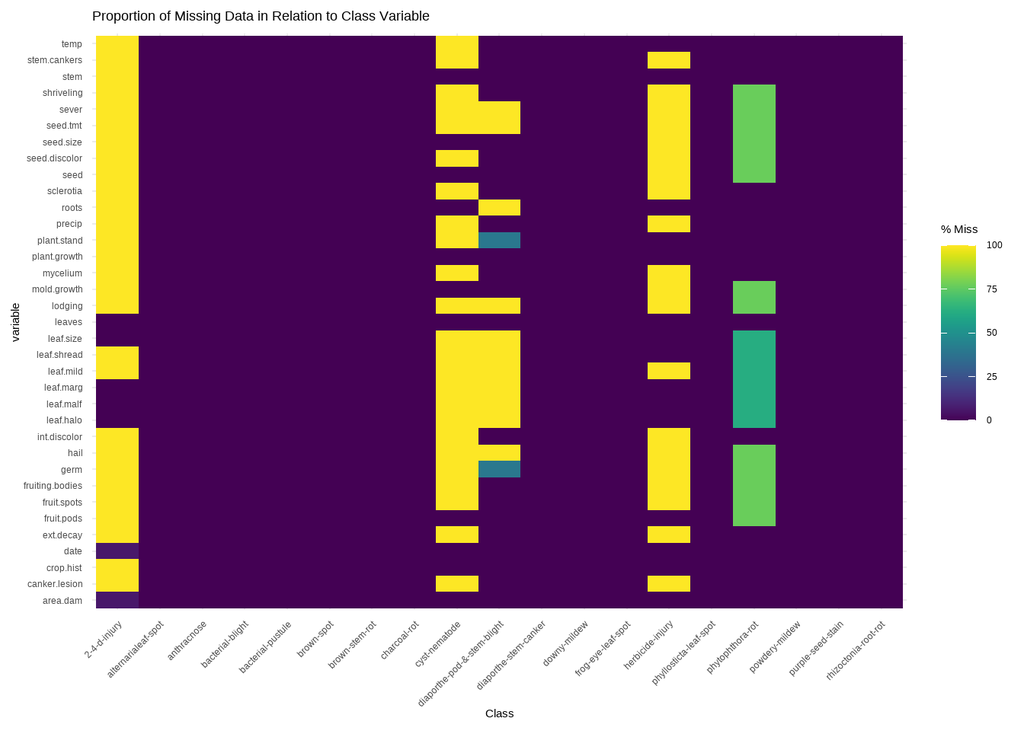

```r
#plot missingness in relation to Class variable -- from Naniar package

gg_miss_fct(soybean, fct = Class)+labs(title='Proportion of Missing Data in Relation to Class Variable')
```

3.2c. Develop a strategy for handling missing data, either by eliminating predictors or imputation.

*Given that the proportion of missing data with any of our covariates is relatively low (< ~ 17%), I would be inclined to impute values using multivariate imputation with chained equations. This method often works well for categorical variables. I would also evaluate other options to reduce missingness prior to impution. These options could include dropping any covariate(s) with a degenerate distribution and/or near zero variance (e.g., mycelium, sclerotia) and/or dropping a covariate(s) that is highly correlated with other predictors. The latter can be evaluated via pairwise correlation and/or variance inflation factors.*

*There are yet other options for identifying/dropping covariates with low predictive value (e.g., PCA, Information Gain). I might defer to one or more these if other options don’t yield satisfactory results.*